In order to sustain a balance between cell loss and

replacement, cells should be capable of self-renewal

as well as differentiation. Stem/progenitor cells ﬁrst

described in 1964, lying at the heart of this process as

the functional units of regeneration, are clonogenic

populations that can give rise to various cell lin-

eages [4, 5]. As their therapeutic potential has already

been demonstrated in different settings, stem cells

novel applications for clinical and preclinical trials

are of great interest, which will hopefully enable the

promise of regenerative medicine to be accomplished

[6, 7].

Currently, the incurable neurodegenerative dis-

eases reached a staggering prevalence [8]. For

example, in the United States, the prevalence of

Alzheimer’s disease (AD) is estimated at 4.7 million

cases and is expected to continue increasing dramat-

ically [9]. The lack of deﬁnitive treatment to such

*H. Salem et al. / Potential Innovative Role of Stem Cells in AD Management*

reviews, editorials, communications, opinions, let-

ters, news, and reports. Also, any study that used

concomitant treatment with stem cells or entailed

indirect cell use (e.g., cells’ medium, endogenous

stemcellpopulationactivationorinﬂammatorymedi-

ators derived from the cells) was excluded. This

systematic review focused on direct cells application

studies only. We used several electronic databases

(PubMed, Google Scholar, Elsevier ScienceDirect,

SpringerLink and PsycINFO) and the keywords

“STEM CELLS, NEURODEGENERATIVE DISE-

ASES, ALZHEIMER’S, PRECLINICAL, CLINIAL

TRIALS” for search. In addition, we searched the

http://www.clinicaltrials.gov website to compare the

results of our search with the existing ongoing or ﬁn-

ished clinical trials (Table 2). All the results were

double checked to ensure they meet the mentioned

criteria.

It is should be noted that almost all trials regard-

ing the use of the pluripotent stem cells are bench

side studies. Thus, we decided to include some bench

side studies in a short paragraph on the topic about

pluripotent cells to be more comprehensive regarding

all the potentially beneﬁcial stem cells types.

*Data handling*

Different levels of categorizations were done. We

divided the articles into clinical and preclinical, then

we further categorized them according to four impor-

tant parameters (variables): year of publication, AD

model (animal or human subjects), type of stem cells

used, and route of cells administration. Published

articles from the same research group that present

different data regarding a research trial are treated as

separate articles.

**RESULTS**

Our search yielded 65 articles published between

2006 and 2016 fulﬁlling our criteria (Fig. 1),

in addition to 13 listed clinical trials on http://

clinicaltrials.gov(listedinTable2).Oneofthestudies

compared the use of two separate groups of animals

with two different routes of cells injection each with

its own control group (4 groups in total), therefore

this study was considered as two independent stud-

ies. Collectively after adjustment, 66 studies were

further analyzed (Table 1). Only one clinical study

was found, while the remaining studies were all pre-

clinical ones.

*H. Salem et al. / Potential Innovative Role of Stem Cells in AD Management*

1211

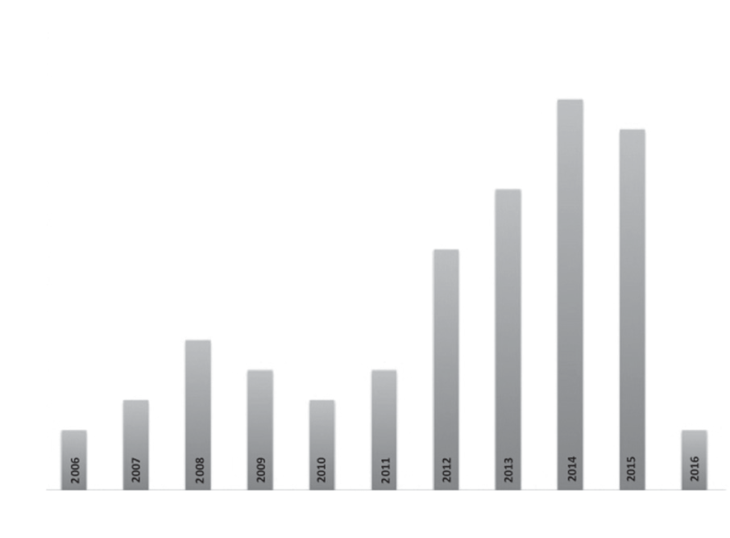

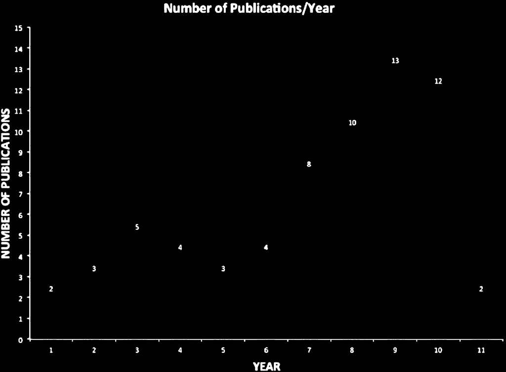

on the other side [24]. In another debatable study,

it was shown that MSCs direct transplantation into

the hippocampus can improve cognition in C57BL/6

mice, as well as augmentation of hippocampal neu-

rogenesis, allegedly through *Wnt* signaling pathway,

thus enhancing endogenous repair [25]. MSCs that

overexpress the vascular endothelial growth factor

was shown to improve neovascularization and the

clearance of A�, ultimately leading to memory and

learning deﬁcits recovery in 2xTg-AD animals [26].

However, a major concern in the study was that in

older animals (12 months), the condition was wors-

ened by the accentuated neurodegeneration caused

by the AD genotype. Moreover, the robust effect

of the VEGF in improving social memory deﬁcit

seen in younger animals was attenuated in older

animals and no reverse of the impairment of the

social recognition memory was accomplished at that

age.

In an interesting study set to investigate the poten-

tial role of MSCs in treating early AD, high-risk

pre-dementia A�PP mice models were treated with

MSC from the bone marrow. Two months post injec-

tion, a reduction in A� deposits and changes in

key proteins required for synaptic transmission were

detected, suggesting a potential early interventional

therapy in prodromal AD by bone marrow-MSC

transplantation [27].

*H. Salem et al. / Potential Innovative Role of Stem Cells in AD Management*

Table 1

Summary of evidence regarding the use of stem cells in Alzheimer’s disease

Cell Type

Cell

Main ﬁndings

Reference

Routing

MSCs

IC

Human MSCs reduced the potentially neurotoxic 56

kDa A� oligomers, increased the endogenous

neurogenesis in the SVZ, and maintained the

glutamate transport systems in the entorhinal

cortex, thus leading to a smaller working memory

deﬁcit in AD models.

Ruzicka et al.,

[110]

UCBCs

IV

UCBCs reach several tissues including the brain

following a single IV treatment. Low IV dose of

UCBCs led to eventual loss of these cells in key

organs, such as the spleen, thus the use of multiple

low-dose infusions in AD models may be

necessary to prolong the therapeutic beneﬁt of

these cells.

Ehrhart et al., [66]

MSCs

IC

Stereotactic administration of MSCs into the

hippocampus and precuneus of human subjects

was feasible, safe, and well tolerated. A phase 1

clinical trial.

Kim et al., [61]

MSCs

IV

Wharton Jelly-derived cells led to a signiﬁcant

reduction in A� deposition and soluble A� levels,

with a signiﬁcantly increased expression of the

anti-inﬂammatory cytokine IL-10 and

down-regulation of pro-inﬂammatory cytokines

IL-1� and TNF-�. Thus, improving the spatial

learning and alleviated the memory decline.

Xie et al., [111]

BMMNCs

IV

Transplantation of BMMCs suppressed neuronal

loss and reduced A� deposition in the brain,

leading to restoration of memory impairment of

DAL transgenic mice to almost the same level as

in wild-type mice.

Kanamaru et al.,

[28]

iPSCs derived

neural cells

IC

ChAT-positive neurons and alpha7 nicotinic

acetylcholine receptor (�7nAChR)-positive

neurons were signiﬁcantly increased in the cortex

and hippocampus with signiﬁcantly increased

number of GABA receptor-positive neurons of

both human origin and mouse origin compared

with those in the vehicle-injected mouse cortex.

Fujiwara et al.,

[112]

MSCs

IC

Repeated administration of MSCs markedly

promoted the expression of synaptic vesicle

markers, including synaptophysin, which are

usually downregulated in patients with AD.

Kim et al., [113]

NSCs

IC

Optimal time frame of cells injection was crucial to

obtain maximal therapeutic effects that can restore

functional deﬁcits or stop the progression of AD.

Kim et al., [41]

NSCs

IC

NSCs transplantation resulted in signiﬁcant decrease

in activation of GFAP, Iba-1, TLR4 and TLR4

pathway-related agents (MyD88, TRIF, P38

MAPK, and NF-*κ*B P65) with decreased

expression of pro-inﬂammatory mediators (IL-1,

IL-6, TNF-� and PGE2).

Zhang et al., [39]

NSCs

IC

Number of mitochondria and expression of

mitochondria-related proteins, speciﬁcally the

mitochondrial ﬁssion factors [dynamin-related

protein 1 (Drp1) and ﬁssion 1 (Fis1)] and the

mitochondrial fusion factor optic atrophy 1

(OPA1), were signiﬁcantly increased with NSCs

transplantation.

Zhang et al., [40]

(*Continued*)

*H. Salem et al. / Potential Innovative Role of Stem Cells in AD Management*

1213

Table 1

(*Continued*)

Cell Type

Cell

Main ﬁndings

Reference

Routing

NSCs

IC

NSCs transplantation reduced tau phosphorylation

via Trk-dependent Akt/GSK3� signaling,

down-regulated A� production through an

Akt/GSK3� signaling-mediated decrease in

BACE1, and decreased expression of

inﬂammatory mediators through deactivation of

microglia that was mediated by cell-to-cell

contact, secretion of anti-inﬂammatory factors. It

also facilitated synaptic plasticity and

anti-apoptotic function via trophic supplies.

Lee et al., [114]

NSCs

IC

Human NSCs cells can migrate and differentiate

into immature neurons and glia and signiﬁcantly

increase synaptic and growth-associated markers.

Transplantation ameliorated context and spatial

learning and memory impairments in transgenic

models of AD.

Ager et al., [42]

NSCs

IC

After NSCs transplantation, the number of basal

forebrain cholinergic neurons, hippocampal

synaptophysin, and AchE-positive ﬁbers were all

signiﬁcantly larger than the control group.

Chen et al., [115]

NSCs

IC

Stereological analysis of engrafted Olfactory Bulb

NSCs eight weeks post transplantation revealed a

1.89 fold increase with respect to the initial cell

population, indicating a marked ability for

survival and proliferation. In addition, 54.71 ±

11.38%, 30.18 ± 6.00%, and 15.09 ± 5.38% of

engrafted cells were identiﬁed by morphological

criteria suggestive of mature neurons,

oligodendrocytes and astrocytes, respectively.

Marei et al., [18]

MSCs

IC

MSC-VEGF treatment favored the

neovascularization and diminished senile plaques

in hippocampal speciﬁc layers. Consequently, the

treatment was able to provide behavioral beneﬁts

and reduce cognitive deﬁcits by recovering the

innate interest to novelty and counteracting

memory deﬁcits in AD transgenic animals.

Garcia et al., [26]

MSCs

IN

Transplanted cells showed predominant distribution

within the olfactory bulb and brainstem.

Danielyan et al.,

[72]

MSCs

IV

Placenta derived cells attenuated the expression of

A�PP, BACE1, and A�, as well as the activity of

�-secretase and �-secretase. In addition, they

inhibited the activation of glia cells and the

increased expression of inducible nitric oxide

synthase and cyclooxygenase-2.

Yun et al., [19]

MSCs

IV

Bone Marrow MSCs were able to home at the

injured brains and produced signiﬁcant increase in

the number of positive cells for ChAT, as well as

selective AD indicator-1 (seladin-1), and nestin

gene expression. Histopathological examination

indicated that they could also remove

beta-amyloid plaques from hippocampus.

Salem et al., [116]

ADSCs

IV

ADSCs labeled with LEO-LIVE-Magnoxide were

still detected *in vivo* 12 days after injection.

Ha et al., [117]

NSCs

IC

A� plaque loads were reduced not only in the

hippocampus and subiculum adjacent to engrafted

NSCs, but also within the amygdala and medial

septum, areas that receive afferent projections

from the engrafted region.

Blurton-Jones

et al., [76]

(*Continued*)

*H. Salem et al. / Potential Innovative Role of Stem Cells in AD Management*

Table 1

(*Continued*)

Cell Type

Cell

Main ﬁndings

Reference

Routing

NSCs

IC

Nissl staining revealed that the number of neurons in

the hippocampus of a transgenic model of AD

(3×Tg mice) receiving NSCs was signiﬁcantly

greater than the control group, indicating that new

neurons were generated. NSC transplantation can

improve spatial learning and memory via neuronal

regeneration.

Chen et al., [118]

ADSCs

IC

ADSCs transplantation enhanced neurogenic

activity in the SVZ with reduced oxidative stress

and alleviated cognitive impairment in the mice.

Based on these ﬁndings, it was proposed that

ADSCs enhances endogenous neurogenesis in

both the subgranular and subventricular zones.

Yan et al., [119]

MSCs

IV

Combined MSCs and erythropoietin markedly

reduced lipopolysaccharide mediated cell damage

in AD model, leading to effective relief of AD

pathology.

Khairallah et al.,

[120]

ADSCs

IV & IC

IV or IC transplanted human ADSCs greatly

improved the memory impairment and the

neuropathology.

Chang et al., [14]

NSCs

IC

NSC-induced neurons highly expressed SYN and

growth associated protein-43 (GAP-43) in

hippocampal areas.

Gu et al., [121]

NSCs

IC

The improvement in cognitive function was

correlated with enhanced long-term potentiation

(LTP) and an increase in the neuron expression of

proteins related to cognitive function:

N-methyl-D-aspartate (NMDA) 2B unit, SYP,

protein kinase C *ζ* subtypes (PKC*ζ*), tyrosine

receptor kinase B (TrkB) and BDNF.

Zhang et al., [122]

NSCs

IC

The expression of SYN and growth-associated

protein-43 (GAP-43) in Tg-NSC mice, 8 weeks

after transplantation, were signiﬁcantly improved.

This was conﬁrmed by the increase in the number

of synapses in Tg-NSC mice as observed via

electron microscopy.

Zhang et al., [123]

NSCs

IC

Transplantation of transgenic IL-1 receptor

antagonist (IL-1ra TG) NSCs one month before

the neurobehavioral disturbances completely

rescued the brain and signiﬁcantly increased the

number of endogenous hippocampal cells

expressing the plasticity-related molecule BDNF.

Ben-Menachem-

Zidon et al.,

[124]

MSCs

IV & IC

MSCs transplantation improved spatial memory in

bulbectomized mice with AD-type

neurodegeneration and no cases of malignant

transformation were noted.

Bobkova et al.,

[125]

MSCs

IC

In transplanted models, M2-like microglial

activation was signiﬁcantly increased, and the

expression of anti-inﬂammatory cytokine

associated with M2-like microglia, IL-4, was also

increased, whereas the expression of

pro-inﬂammatory cytokines associated with

classic microglia (M1-like microglia), including

IL-1� and TNF-� was signiﬁcantly reduced.

Yang et al., [20]

(*Continued*)

*H. Salem et al. / Potential Innovative Role of Stem Cells in AD Management*

1215

Table 1

(*Continued*)

Cell Type

Cell

Main ﬁndings

Reference

Routing

NSCs

IC

No difference was detected in total number of A�

plaques between NSC and control groups after

transplantation. Also, there was no difference in

the number of thioﬂavin-S-positive (TS+) plaques

between both groups after eight weeks of NSCs

transplantation. However, engrafted NSCs showed

partial chemotaxis toward A� plaques.

Zhang et al, [126]

UCBCs

IV

UCBC therapy correlated with decreased cognitive

impairment, A� levels/A� plaques,

amyloidogenic A�PP processing, and reactive

microgliosis after a treatment of 6 or 10 months.

Darlington et al.,

[48]

MSCs

IC

Single IC injection of bone marrow-MSCs resulted

in signiﬁcant decrease in the cerebral A�

deposition sustained up to 2 months. Expression

of dynamin 1 and Synapsin 1, key pre-synaptic

proteins associated with synaptic transmission,

were considerably enhanced in the brains of AD

mice sustained beyond 2 months.

Bae et al., [27]

ADSCs

IC

ADSC transplantation dramatically reduced A�

deposition and signiﬁcantly restored the

learning/memory function in A�PP/PS1

transgenic mice with more activated microglia.

Ma et al., [52]

MSCs

Intracardiac

Systemic transplantation of autologous T regulatory

cells (Tregs) signiﬁcantly ameliorate the cognition

and reduced the A� plaque deposition and the

levels of soluble A�, accompanied with

signiﬁcantly decreased levels of activated

microglia and systemic inﬂammatory factors.

Yang et al., [20]

MSCs

IV

Six weeks after the IV injection of MSCs, mice

models showed evidence of improved spatial

learning, which signiﬁcantly correlated with the

observation of fewer A� plaques in brain.

Furthermore, the level of pro-inﬂammatory

cytokines, IL-1 and TNF-�, was lower while the

anti-inﬂammatory cytokines, IL-10 and

transforming growth factor-�, was higher in

MSC-injected mice the controls. These effects

lasted until 12 weeks after injection.

Kim et al., [21]

MSCs

IV

At 13 and 14 days, MSC transplantation group

showed signiﬁcantly improved spatial learning

and memory ability than controls. 14 days after

transplantation in rat hippocampus,

PKH26-positive cells could be found consistent

with DAPI staining. PKH26-positive cells in

animal models of AD were signiﬁcantly more

than those in the normal control group.

Li et al., [127]

MSCs

IV

When MSCs were transplanted into the

hippocampus of a 10-month-old transgenic mouse

model of AD for 10, 20, or 40 days, NEP

expression was increased in the mice brains.

Moreover, A�42 plaques in the hippocampus and

other regions were decreased by active migration

of MSCs toward A� deposits. This suggests that

MSC-derived sICAM-1 decreases A� plaques by

inducing neprilysin expression in microglia

through the sICAM-1/LFA-1 signaling pathway.

Kim et al., [128]

NSCs

IC

(1)H-MRS displayed IC metabolite changes before

and after NSC transplantation in AD mice models

and had an applicable value in evaluating the

therapeutic effect of NSCs on AD.

Chen et al., [129]

(*Continued*)

*H. Salem et al. / Potential Innovative Role of Stem Cells in AD Management*

Table 1

(*Continued*)

Cell Type

Cell

Main ﬁndings

Reference

Routing

ADSCs

IV & IC

Intravenously transplanted ADSCs passed through

the BBB and migrated into the brain. The

learning, memory and pathology in an AD mouse

model (Tg2576 mice) greatly improved for at

least 4 months after IV injection of the cells.

Kim et al., [53]

NSCs

IC

Authors showed that transplanted epidermal-NSCs

survived and produced many neurons and a few

glial cells, presenting glial ﬁbrillary acidic

protein. In addition, the total number of granule

cells in hippocampus was higher in the AD model

with transplanted cells as compared to the control

group.

Esmaeilzade et al.,

[54]

Amniotic stem

cells

IC

Amniotic stem cells transplantation signiﬁcantly

ameliorated spatial memory deﬁcits in AD

transgenic mice, as well as increased

acetylcholine levels and the number of

hippocampal cholinergic neurites.

Xue et al., [130]

NSCs

IC

Transplantation of F3. ChAT human NSCs fully

recovered the learning and memory function of

AF64A animals, and induced elevated levels of

acetylcholine in cerebrospinal ﬂuid. Transplanted

F3.ChAT human NSCs were found to migrate to

various brain regions including cerebral cortex,

hippocampus, striatum and septum, and

differentiated into neurons and astrocytes

Park et al., [131]

MSCs

IC

A� deposition, BACE1 levels, and tau

hyperphosphorylation were dramatically reduced

in MSC transplanted A�PP/PS1 mice. These

effects were associated with reversal of

disease-associated microglial neuroinﬂammation,

as evidenced by decreased microglia-induced

pro-inﬂammatory cytokines, elevated alternatively

activated microglia, and increased

anti-inﬂammatory cytokines.

Lee et al., [24]

MSCs

IC

Intraventricular transplantation of native and

glucagon-like peptide-1 transfected MSC was

shown to be effective. Decreased amyloid

deposition or suppression of glial and microglial

responses were observed.

Klinge et al., [132]

Amniotic

epithelial

cells

IC

Transplanted amniotic cells can survive for at least 8

weeks and migrate to the third ventricle without

immune rejection. Not only they signiﬁcantly

improved the spatial memory of the AD

transgenic mice, but they also increased

acetylcholine concentration and the number of

hippocampal cholinergic neurites.

Xue et al., [133]

MSCs

IC

Immunohistochemistry showed that GFP-MSCs

distributed uniformly and the number of

Alzheimer’s senile plaques reduced after

transplantation, leading to retard AD-like

pathology and upregulation of DeltaNp73

expression in hippocampus of A�PP/PS1

transgenic mice.

Wen et al., [134]

(*Continued*)

*H. Salem et al. / Potential Innovative Role of Stem Cells in AD Management*

1217

Table 1

(*Continued*)

Cell Type

Cell

Main ﬁndings

Reference

Routing

MSCs

IC

Immortalized MSCs possessed better ability of

proliferation and anti-senescence compared with

primary MSCs, while maintained multilineage

differentiation capacity. Neural-like cells derived

from immortalized MSCs had similar expressions

of neural-speciﬁc genes, protein expression

patterns and resting membrane potential (RMP)

compared with their counterparts derived from

primary MSCs; they play same role as primary

MSCs in improving learning ability and spatial

memory in AD models.

Gong et al., [135]

MSCs

IC

MSCs reduced the hippocampal apoptosis.

Moreover, acute markers of glial activation,

oxidative stress and apoptosis levels were

decreased in AD mouse brain. MSCs treated AD

mice demonstrated cognitive rescue with

restoration of learning/memory function.

Lee et al., [136]

NSCs

IC

Histological examinations showed that there was no

obvious changes in A� deposition between tested

groups; in addition, the NSCs differentiated and

expressed neuronal nuclei-positive cells, and

continuously expressed

5-bromodeoxyuridine-positive cells for six weeks.

He et al., [137]

MSCs

IC

MSCs attenuated A�-induced apoptotic cell death in

primary cultured hippocampal neurons by

activation of the cell survival signaling pathway.

These anti-apoptotic effects of MSCs were also

observed in an acutely-induced AD mice model

produced by injecting A� intrahippocampally. In

addition, MSCs diminished A� -induced

oxidative stress and spatial memory impairment in

the *in vivo* model.

Lee et al., [74]

MSCs

IC

MSCs into A�PP/PS1 mice signiﬁcantly reduced

A� deposition with decreased tau

hyperphosphorylation and improved cognitive

function. These effects were associated with

restoration of defective microglial function,

evidenced by increased A�-degrading factors,

decreased inﬂammatory responses, and elevation

of alternatively activated microglial markers.

Lee et al., [73]

NPCs

IC

NPCs transplantation signiﬁcantly reduced

microgliosis (by 38%), but not astrogliosis in

peptide-injected hippocampus.

Ryu et al., [138]

NPCs

IC

Immunohistochemical analysis revealed that the

majority (approximately 70%) of the NPCs

retained neuronal phenotype and approximately

40% of them had a cholinergic cell phenotype

following transplantation with no tumor

formation, indicating that NPCs may be safe for

transplantation. Behavioral assessment revealed a

signiﬁcant behavioral improvement in memory

deﬁcits following transplantation with NPCs.

Moghadam et al.,

[37]

NSCs

IC

The number of cholinergic neurons of the

NSCs-transplanted group was signiﬁcant higher

than that of the glia-transplanted group in medial

septum and vertical diagonal branch. The results

indicate that transplanted NSCs can differentiate

into cholinergic neurons, which may play an

important role in the therapeutic effects of

transplanted NSCs.

Xuan et al., [139]

(*Continued*)

*H. Salem et al. / Potential Innovative Role of Stem Cells in AD Management*

Table 1

(*Continued*)

Cell Type

Cell

Main ﬁndings

Reference

Routing

NSCs

IC

BDNF can enhance the treatment effects of NSCs

transplanted into brain lesion model as shown by

immunohistochemical detection of p75(NGFR)

indicating that the number of cholinergic neurons

of the had more signiﬁcant improvement

Xuan et al., [140]

NSCs

IC

NSCs survived after transplantation, integrated into

the host brain and enhanced cognitive

performance.

Wu et al., [141]

NPCs

IC

The development of amyloidosis in the neurogenic

regions attenuated the age-associated reduction of

proliferation of NPCs, proving that their

proliferation in culture did not depend on the age

or presence of A�PP-transgene.

Kolecki et al.,

[142]

UCBCs

IV

UCBC infusions reduced cerebral vascular A�

deposits in the Tg2576 AD mouse model. These

effects were associated with suppression of the

CD40-CD40L interaction, as evidenced by

decreased circulating and brain soluble CD40L

(sCD40L), elevated systemic immunoglobulin M

(IgM) levels, attenuated CD40L-induced

inﬂammatory responses, and reduced surface

expression of CD40 on microglia.

Nikolic et al.,

[143]

MSCs

IC

Results showed that MSCS survived, migrated and

expressed NGF as well as differentiated into

ChAT-positive neurons with a signiﬁcant

improvement in learning and memory in AD rats.

Li et al., [144]

NSCs

IC

NSCs transplanted into the brain after neuronal

ablation survived, migrated, differentiated and,

most signiﬁcantly, improved memory.

Yamasaki et al.,

[145]

NSCs

IV

After transplantation at different time points, NSCs

were diffusely distributed in the brain and around

the blood vessels in the ﬁrst 48 h, then migrated

gradually towards the hippocampus and cortex

until 4 weeks later.

Zhan et al., [146]

NSCs

IC

Not only NSCs survived well after transplantation

into hippocampus of AD rats, but also they

possessed the capacity of continuous proliferation

and migrated along the hippocampus.

Yang et al., [147]

NSCs

IC

Neurospheres transplanted into the mouse cortex

survived and produced many ChAT-positive

neurons and a few serotonin-positive neurons in

and around the grafts, thus decreasing signiﬁcantly

the working memory error in the mice.

Wang et al., [148]

NSCs

IC

The behavioral amelioration of AD model rat was

obtained by transplanting single NSCs and

BDNF-gene-modiﬁed NSCs. The effect of the

NSCs group modiﬁed with BDNF gene proved to

be better than NSCs alone.

Zhao et al., [149]

*H. Salem et al. / Potential Innovative Role of Stem Cells in AD Management*

1219

Table 2

Clinical trials performed for testing stem cells therapy in Alzheimer’s disease

Type of cell / Drug

Design/type

Classiﬁcation

Estimated enrollment/

Outcomes

Follow-up period

Longeveron

mesenchymal

stem cells

Randomized/

Interventional

Double blind

Safety

demonstration

(Phase I)

30 subjects Follow up:

primary outcome:

ﬁrst 30 days.

Secondary

outcome: 2, 6, 13,

26, 39 & 52 post

infusion

Not yet recruiting

Human umbilical

cord blood

derived

mesenchymal

Stem cells

Randomized/

Interventional

Double blind

Safety and

Exploratory

Efﬁcacy Versus

Placebo (Phase

I and II)

42 subjects Follow up:

24 weeks after the

ﬁrst dose

Recruiting

Adult neuronal

Progenitor stem

cell culture

Interventional/

Open label

Exploratory

Efﬁcacy (Phase

II)

10 subjects Follow up:

not provided

Not yet recruiting

Human Umbilical

cord derived

MSCs

Interventional/

Open label

Safety and

Efﬁciency

(Phase I and II)

30 subjects Follow up:

10 weeks

post-administration

and year

Not yet recruiting

Human Umbilical

cord derived

MSCs

Interventional/

Open label

Safety and

Efﬁciency

(Phase I)

9 subjects Follow up:

12 weeks

post-administration

Completed with no

published results

yet

Human Umbilical

cord derived

MSCs

Interventional/

Double Blind

Safety and

Exploratory

Efﬁcacy (Phase

I and II)

40 subjects Follow up:

10 weeks

post-administration

Not yet recruiting

Human Umbilical

cord derived

MSCs

Observational/

Case Control/

Prospective

Safety and

Exploratory

Efﬁcacy (Phase

I and II)

14 subjects Follow up:

24 months postop

Recruitment status is

unknown

Human Umbilical

cord derived

MSCs

Randomized/

Interventional

Double blind

Safety and

Exploratory

Efﬁcacy (Phase

I and II)

40 subjects Follow up:

10 weeks

post-administration

Not yet recruiting

Panax Ginseng

Non-Randomized/

Interventional

Open label

Safety and

Exploratory

Efﬁcacy (Phase

I and II)

Not provided

Completed with no

published results

yet

Mellaril

Interventional/

Open label

Feasibility Study

(Phase 0)

6 subjects Follow up:

24 hours after

treatment

Terminated with no

published results

yet

Induced

pluripotent stem

cells develop-

ment from

donated somatic

cells

Observational/

Case Control/

Prospective

120 subjects Follow

up: not provided

Not yet recruiting

Candesartan

Randomized/

Interventional

Double blind

Exploratory

Efﬁcacy (Phase

II)

72 subjects Follow up:

12 months

Not yet recruiting

Filgrastim

(G-CSF)

Randomized/

Interventional

Double blind

Safety and

Exploratory

Efﬁcacy (Phase

I and II)

8 subjects Follow up:

2 weeks and 4

weeks

Results: Granulocyte

colony stimulating

factor decreased

brain amyloid

burden and reverses

cognitive

impairment in

Alzheimer’s mice

(Sanchez-Ramos

et al., 2009) [150].

*H. Salem et al. / Potential Innovative Role of Stem Cells in AD Management*

[figure not shown]

[figure not shown]

side effects associated with the vector assisted deliv-

ery method (lentivirus, adenovirus, or herpes simplex

virus) they used to deliver the neprilysin to the target

areas. It was also unclear the reason of the adenovirus

delivered neprilysin localization at the presynaptic

sites, whereas the lentivirus localization was in the

cell soma and the endoplasmic reticulum [34–36].

Transplantation of neuronal precursor cells (NPCs),

derived from mouse embryonic stem cells (ESCs),

was shown to promote behavioral recovery in a nbM-

lesioned rats AD model following commitment to a

cholinergic cell phenotype [37]. Unlike other pre-

vious studies, it clearly showed an increase in the

number of cholinergic neurons after treatment. Still,

the question whether NPCs is only a cholinergic sur-

vival factor or also contributes to differentiation of

cholinergic neurons is yet to be elucidated.

In an *in vitro* induction study, the combined effect

of both nerve growth factor and brain derived neu-

rotropic factor (BDNF) on NSCs differentiation led

to increased neurogenesis rate, which may be inter-

esting for future clinical applications, especially for

dosage optimization [38]. In addition, NSCs showed

signiﬁcant neuroprotective effect against AD inﬂam-

mation by suppressing glial and toll-like receptor-4

(TLR4) mediated inﬂammatory pathway activation,

leading to down-regulation of the proinﬂammatory

mediators [interleukin-1 (IL-1), IL-6, tumor necro-

sis factor alpha (TNF�)] in A�PP/PS1 mouse model,

thus ameliorating the cognitive deﬁcits, but with no

change in A� concentration [39]. It is worth noticing

the amelioration of cognitive deﬁcits without differ-

ence in A� concentration, but associated with the

*H. Salem et al. / Potential Innovative Role of Stem Cells in AD Management*

1221

maintain unlimited lifetime differentiation along the

three known cell lineages (multipotent) [43].

*Human umbilical cord blood cells (HUCBCs).*

HUCBCs transplantation has been therapeutically

beneﬁcial in many neurodegenerative disorders [44].

Despite acknowledged as clinical waste, HUCBCs

provide an alternative source for plenty of MSCs [45].

They have been suggested to modulate the periph-

eral inﬂammatory processes, which in turn affect

inﬂammation in the brain parenchyma, and the mobi-

lization of adult stem cells from the bone marrow,

leading to extension of the lifespan in A�PP mice [46,

47]. Multiple low doses of HUCBCs were shown to

improve cognitive impairment, reduce A�-associated

neuropathology, and improve the motor skills in long

term treated AD mice [48]. Despite the usage of mul-

tiple doses to detect the optimum one in those studies,

the problem of dose optimization is yet to be solved.

*Adiposetissuederivedstemcells(ADSCs).*ADSCs

appeared as a new attractive source for stem cells in

regenerativetherapyastheyarereadilyabundant,eas-

ily accessible, with a detected lower senescence ratio

compared to bone marrow-MSCs [49]. In addition,

they are known for their ability to differentiate into

mesenchymal and non-mesenchymal lineages [50].

One study proposed ADSCs as a safe stem cell source

for intravenous (IV) injections, owing to the absence

of immune rejections, ethical problems or tumorigen-

esis. [51]. Long term follow-up (up to 26 months post

injection) to determine their potential tumorigenicity

in nude mice showed ADSCs to be safe even with

high doses.

In AD, intracerebral (IC) transplanted or intra-

venous (IV) administered ADSCs showed dramatic

improvement of impaired memory and neuropathol-

ogy in A�PP/PS1 mice models, with huge reduction

of A� peptide deposition with microglial activation,

thus suggesting that they have a high therapeutic

potential for AD [17, 52]. It was very interest-

ing to show that in cases of IV ADSC delivery,

the labeled ﬂuorescence magnetic nanoparticles for

*in vivo* live tracking were demonstrated in all brain

regions except the olfactory bulb in Tg2576 model

[53]. This study highlights once more the importance

of the early detection and intervention in AD, as the

early onset injected cells produced major changes in

the disease progress and pathology, while late onset

treatment was minimally effective.

*Hair follicle stem cells = Epidermal neural crest*

*derived stem cells (Epi-NCSCs).* A very interesting

study assessed the ability of Epi-NCSCs derived from

hair follicles, which are the multipotent remnants of

*H. Salem et al. / Potential Innovative Role of Stem Cells in AD Management*

[60]. A recent phase-one clinical trial used the same

reported successful stereotactic surgery to deliver

MSCs intracerebrally, directly into the hippocampus

and the precuneus, which was proven to be feasible,

safe, and well tolerated [61]. Despite lacking a con-

trol group in both studies and the small study sample

(10 and 9, respectively), they both proved interven-

tional safety, thus opening the gate for future more

controlled wide scale evidence-based clinical trials.

Choosing a cell delivery route for clinical trans-

lation is a huge challenge, since the human brain is

considerably larger than the mouse brain (the most

used animal model for AD). Peripheral delivery of

cells and proteins appears to be less effective than

intracerebral injections. For instance, a study found

that IV delivery route could reduce plasma A�, but

failed to clear A� plaques within the brain [62].

Kanamaru and colleagues rationally debated the

need for other less invasive ways of cell delivery,

particularly in humans [28]. Based on the theory

of blood-brain barrier disruption and leakage in AD

patients [63, 64], lots of researchers have constructed

their preclinical experiments using the IV route for

cell delivery, as an easier and less invasive method.

Although Lee and colleagues in 2008 postulated that

NSCs are best delivered IV than IC, they also men-

tioned that in case of MSCs IV injection, most of the

injectedcellswerefoundinthesplenicmarginalzone,

rather than homing in the brain tissues [65]. This was

also consistent with the results of IV injection of cord

blood cells that were found all over the body of a

murine model [66]. Moreover, Yang and colleagues

ﬁrst reported that the IV injection of BMMNCs is

not inferior to the intra-arterial route. Interestingly,

Kanamaru and colleagues also reported the inability

to detect the IV injected cells in brain tissues after 3

months of transplantation [28]. Such reports illustrate

the unpredictable fate of the IV route, and the min-

imal percentage of localization of the injected cells

centrally (in the brain), despite its apparent efﬁcacy,

which render this technique debatable.

Direct intra-arterial stem cells transplantation has

been used mainly for stroke and ischemic diseases

to induce functional recovery in the acute therapeutic

window [67, 68]. In 6-hydroxydopamine (6-OHDA)-

induced animal model of Parkinson’s disease, MSCs

were directly infused in the carotid artery. System-

ically injected cells could not efﬁciently cross the

blood-brain barrier to home in the nigrostriatal region

unless another agent is given with them facilitat-

ing their permeability [69]. Such technique is not

employed so far for stem cells delivery in AD.

*H. Salem et al. / Potential Innovative Role of Stem Cells in AD Management*

1223

A more recent explanation to stem cells’ effects

is the role of the extracellular vesicles as key com-

ponents of their paracrine effect. Various types of

stem cells release ‘secretomes’. Studies have shown

that they deliver bio-active cargo to the neighboring

diseased or injured cells, modifying the cellu-

lar receptors function, inducing anti-inﬂammatory,

immune modulation, angiogenesis, neurogenesis and

synaptogenesis [81–84]. Moreover, recent reports

linked them as mediators to intercellular communica-

tion in cancer [85], which warrants more elucidation

on their mechanism of action.

In spite of the numerous trials along the past

decade to unravel the actual mechanism by which

stem cells induce their effect, to date, it is still largely

unknown and mostly hypothetical. Furthermore,

despite their promise, secretomes clinical application

still faces several challenges, including their iso-

lation and production techniques (time consuming

ultracentrifugation is the only available technique so

far) and heterogeneity.

*In vivo stem cell tracking*

One of the biggest challenges that face all sorts of

stemcellstherapiesisthelackofreliable*invivo*imag-

ing methods to evaluate the biological interactions of

transplanted cells [86].

Nanomedicine and nanoparticles-based delivery

systems for stem cells are very interesting. Super-

paramagnetic iron oxide has been used for decades

to track stem cells *in vivo* after *in vitro* labeling.

Nanotechnologies revolutionized the high resolution

of *in vivo* imaging for cell tracking [87]. Magnetic

resonance imaging (MRI), positron emission tomog-

raphy (PET), or single-photon emission computed

tomography are used to visualize the labeled stem

cells *in vivo*. MRI imaging has the advantage of high

spatial resolution and anatomical information but its

major drawback is the limited sensitivity [88–90].

PET scans are highly sensitive but have low spa-

tial resolution, poor in anatomical delineation, with

notable short half-life of the radioisotopes [91, 92].

Fluorescence imaging is another noninvasive imag-

ing method for *in vivo* tracking. It is also highly

sensitive with good resolution at the subcellular level,

but suffers from limited penetration power even with

the prolonged release dye techniques [93, 94]. Near-

infrared ﬂuorescence imaging (NIRFI) using NIR

ﬂuorophores improved penetration depth and pro-

vided more speciﬁc signals, but still has a major

drawback of photobleaching [95, 96]. Several mul-

timodal imaging techniques have been developed

*H. Salem et al. / Potential Innovative Role of Stem Cells in AD Management*

phenotypes such as increased A�42 production and

tau-phosphorylation changes, they are very important

for *in vitro* study models. Very interestingly, com-

pounds that inhibit gamma-secretase activity were

effective at reducing A� production in AD iPSC-

derived neuronal cultures, a concept used in drug

screening studies. This will hopefully lead to ratio-

nal selection of the most successful pharmacological

strategy for preventing early AD changes [107].

Thisnewstemcellsfrontierwillenablescientiststo

genuinely study human-based AD pathology and its

response to genetic and pharmacologic manipulation,

for more effective future clinical applications.

**CONCLUSION AND FUTURE**

**PERSPECTIVES**

Cell based therapies offer promising results, but

it is clear that they still need more research to opti-

mize lots of hanging problems around them. On one

hand, the potential of regeneration of brain tissue

using stem cells is sure. On the other hand, we still

do not know the best way to deliver these cells to the

brain. The complexity of neurodegenerative diseases

results in difﬁculty in optimizing a single direct cell

based therapy to reverse all the effects, particularly

AD, in which there is no uniform disease progression

with multiple levels of pathological changes incorpo-

rated along different time points (early, intermediate,

and late courses). This is one of the major hurdles

that face a potential cell based therapy to such com-

plex disease process. NSCs, claimed to be the best

and most effective type for AD management, need

proper optimization regarding doses and mode of

delivery and whether a concomitant treatment should

be administered or not.

In addition, we learned that stem cells are effec-

tive, but we are still incapable of clearly identifying

their mechanistic effects as well as detect them *in*

*vivo* after transplantation, which is in our opinion the

ultimate hurdle facing their clinical applications. It is

paramount to be able to trace your treatment, to detect

its dosage level, its toxicity and cellular interactions,

not just administer it and applauding an outcome that

we are not sure of its cellular level biochemical pro-

cesses yet.

In iPSCs based therapy, the ﬁrst landmark clini-

cal trial on humans was launched in 2014 to treat

macular degeneration [108, 109]. Even though it

started favorably with their ﬁrst patient, an undeﬁned

genomic mutation occurred with the iPSCs of the

*H. Salem et al. / Potential Innovative Role of Stem Cells in AD Management*

1225

chwannoma: A century’s fruition. *World*

906-911.

kop AR (2008) Cell division screens and

*hem Soc Trans* **36**, 431-435.

(2010) Cell theory, speciﬁcity, and repro-

1870. *Stud Hist Philos Biol Biomed Sci* **41**,

bert CW, Porteous DD, Aexanian R (1964)

one-marrow stem-cell population. *Ann N Y*

742-752.

asso R, Reverberi D, Cilli M, Pfeffer U,

015) Identiﬁcation of a new cell popula-

ely circulating in healthy conditions and

a homing ability toward injured sites. *Sci*

hansky L, Blumenthal J, Barash H, War-

azor Y, Shtrichman R (2014) Cell-based

aches: The hope for incurable diseases.

649-672.

S, Park YS (2016) Regenerative applica-

th derived stem cells in other than tooth

A literature review. *Stem Cells Int* **2016**,

H, Kobeissy FH, Itani M, Nokkari A, Wang

tem cells in neuroinjury and neurodegen-

rs: Challenges and future neurotherapeutic

*ral Regen Res* **9**, 901-906.

Weuve J, Scherr PA, Evans DA (2013)

ase in the United States (2010–2050) esti-

e 2010 census. *Neurology* **80**, 1778-1783.

2015) Stem cell treatments for neurode-

ases: Challenges from a science, business

perspective. *Neurodegener Dis Manag* **5**,

*Psychiatry* **64**(Suppl 9), 7-10.

[12]

Burns A, Iliffe S (2009) Alzheimer’s disease. *BMJ* **338**,

b158.

[13]

Desikan RS, Cabral HJ, Hess CP, Dillon WP, Glaston-

bury CM, Weiner MW, Schmansky NJ, Greve DN, Salat

DH, Buckner RL, Fischl B, Alzheimer’s Disease Neu-

roimaging Initiative. (2009) Automated MRI measures

identify individuals with mild cognitive impairment and

Alzheimer’s disease. *Brain* **132**, 2048-2057.

[14]

Kimbrel EA, Lanza R (2015) Current status of pluripotent

stem cells: Moving the ﬁrst therapies to the clinic. *Nat Rev*

*Drug Discov* **14**, 681-692.

[15]

Peng Y, Huang S, Cheng B, Nie X, Enhe J, Feng C, Fu

X (2013) Mesenchymal stem cells: A revolution in thera-

peutic strategies of age-related diseases. *Ageing Res Rev*

**12**, 103-115.

[16]

Bash D, Song L, Tuan RS (2004) Adult mesenchymal stem

cells: Characterization, differentiation, and application in

cell and gene therapy. *J Cell Mol Med* **8**, 301-316.

[17]

Chang KA, Kim HJ, Joo Y, Ha S, Suh YH (2014) The

therapeutic effects of human adipose-derived stem cells in

Alzheimer’s disease mouse models. *Neurodegener Dis* **13**,

99-102.

[18]

Marei HES, Althani A, Aﬁﬁ N, Abd-Elmaksoud A,

Bernardini CFM, Pescatori M, Maira G, Paldino E, Manni

L, Casalbore P, Cenciarelli C (2013) Over-expression of

hNGF in adult human olfactory bulb neural stem cells pro-

motes cell growth and oligodendrocytic differentiation.

*PLoS One* **8**, e82206.

[19]

Yun HM, Kim HS, Park KR, Shin JM, Kang AR, il Lee K,

Song S, Kim YB, Han SB, Chung HM, Hong JT (2013)

Placenta-derived mesenchymal stem cells improve mem-

ory dysfunction in an A�1-42-infused mouse model of

Alzheimer’s disease. *Cell Death Dis* **4**, e958.

[20]

Yang H, Yang H, Xie Z, Wei L, Bi J (2013) Systemic

transplantation of human umbilical cord derived mes-

enchymal stem cells-educated T regulatory cells improved

the impaired cognition in A�PPswe/PS1dE9 transgenic

mice. *PLoS One* **8**, e69129.

[21]

Kim KS, Kim HS, Park JM, Kim HW, Park MK, Lee HS,

Lim DS, Lee TH, Chopp M, Moon J (2013) Long-term

immunomodulatory effect of amniotic stem cells in an

Alzheimer’s disease model. *Neurobiol Aging* **34**, 2408-

2420.

[22]

Majka SM, Jackson KA, Kienstra KA, Majesky MW,

Goodell MA, Hirschi KK (2003) Distinct progenitor pop-

ulations in skeletal muscle are bone marrow derived and

exhibit different cell fates during vascular regeneration.

*J Clin Invest* **111**, 71-79.

[23]

Birch AM, Katsouri L, Sastre M (2014) Modulation of

inﬂammation in transgenic models of Alzheimer’s disease.

*Neuroinﬂammation* **11**, 25.

[24]

Lee HJ, Lee JK, Lee H, Carter JE, Chang JW, Oh W, Yang

YS, Suh JG, Lee BH, Jin HK, Bae JS (2012) Human

umbilical cord blood-derived mesenchymal stem cells

improve neuropathology and cognitive impairment in an

Alzheimer’s disease mouse model through modulation of

neuroinﬂammation. *Neurobiol Aging* **33**, 588-602.

[25]

Oh SH, Kim HN, Park HJ, Shin JY, Lee PH (2015) Mes-

enchymal stem cells increase hippocampal neurogenesis

and neuronal differentiation by enhancing the Wnt sig-

naling pathway in an Alzheimer’s disease model. *Cell*

*Transplant* **24**, 1097-1109.

[26]

Garcia KO, Ornellas FL, Martin PK, Patti CL, Mello LE,

Frussa-Filho R, Han SW, Longo BM (2014) Therapeu-

tic effects of the transplantation of VEGF overexpressing

*H. Salem et al. / Potential Innovative Role of Stem Cells in AD Management*

mesenchymal stem cells in the hippocam-

model of Alzheimer’s disease. *Front Aging*

derived mesenchymal stem cells contribute

n of amyloid-� deposits and the improve-

ptic transmission in a mouse model of

lzheimer’sdisease.*CurrAlzheimerRes***10**,

Kamimura N, Yokota T, Nishimaki K, Iuchi

ami S, Akashiba H, Shitaka Y, Ueda M,

mura K, Ohta S (2015) Intravenous trans-

bone marrow-derived mononuclear cells

ry impairment in transgenic mouse models

disease. *Brain Res* **1605**, 49-58.

JK, Lee JE, Min WK, Schuchman EH,

S (2011) Combined effects of hematopoi-

cell mobilization from bone marrow by

olony stimulating factor and AMD3100

s into the brain using stromal cell-derived

Alzheimer’s disease mouse model. *Stem*

1089.

ory E, Jekerle V, Lucas-Samuel S, Ahnert

¨uscher D, Fibbe W, Foussat A, Kwa M,

ciulaitis R, Palom¨aki T, Schneider CK,

chdjian G, Tarte K, Tosca L, Salmikangas

zalez V, Lavell E, Qui˜nones-Hinojosa A,

res H (2015) Regulation of subventricular

ells migration in the adult brain. *Adv Exp*

1-21.

t B (2014) Mesenchymal stem and progen-

lems, potential and promise. *J Stem Cells*

106.

ez V, Herranz-P´erez V, Garc<sup>´</sup>ia-Verdugo

e aged brain: Genesis and fate of resid-

, Webber DJ, Bilican B, Goedert M,

G, Chandran S (2010) Cell-mediated neu-

n a mouse model of human tauopathy.

9973-9983.

arr RA, Rockenstein E, Crews L, Adame

atrick C, Gage FH, Verma IM, Masliah E

erm neprilysin gene transfer is associated

evels of intracellular Abeta and behavioral

n APP transgenic mice. *BMC Neurosci* **9**,

Cisse M, Ho K, Wu T, Esposito LA,

K, Cheng IH, Yu GQ, Mucke L (2009)

rexpression inhibits plaque formation but

pathogenic Abeta oligomers and associ-

deﬁcits in human amyloid precursor protein

e. *J Neurosci* **29**, 1977-1986.

M, Spencer B, Michael S, Castello NA,

Davis JL, M¨uller FJ, Loring JF, Masliah E,

014) Neural stem cells genetically-modiﬁed

lysin reduce pathology in Alzheimer trans-

*Stem Cell Res Ther* **5**, 46.

H, Alaie H, Karbalaie K, Tanhaei S, Nasr

Baharvand H (2009) Transplantation of

imed mouse embryonic stem cell-derived

or cells improves cognitive function in

ats. *Differentiation* **78**, 59-68.

Chen Y, Zhang J, Xu L, Yan Q, Long D

ed effect of nerve growth factor and brain-

derived neurotrophic factor on neuronal differentiation of

neural stem cells and the potential molecular mechanisms.

*Mol Med Rep* **10**, 1739-1745.

[39]

Zhang Q, Wu HH, Wang Y, Gu GJ, Zhang W, Xia R

(2016) Neural stem cell transplantation decreases neuroin-

ﬂammation in a transgenic mouse model of Alzheimer’s

disease. *J Neurochem* **136**, 815-825.

[40]

Zhang W, Gu GJ, Shen X, Zhang Q, Wang GM, Wang PJ

(2015) Neural stem cell transplantation enhances mito-

chondrial biogenesis in a transgenic mouse model of

Alzheimer’s disease-like pathology. *Neurobiol Aging* **36**,

1282-1292.

[41]

Kim JA, Ha S, Shin KY, Kim S, Lee KJ, Chong YH,

Chang KA, Suh YH (2015) Neural stem cell transplan-

tation at critical period improves learning and memory

through restoring synaptic impairment in Alzheimer’s dis-

ease mouse model. *Cell Death Dis* **6**, e1789.

[42]

Ager RR, Davis JL, Agazaryan A, Benavente F, Poon

WW, LaFerla FM, Blurton-Jones M (2015) Human neu-

ral stem cells improve cognition and promote synaptic

growth in two complementary transgenic models of

Alzheimer’s disease and neuronal loss. *Hippocampus* **25**,

813-826.

[43]

Seaberg RM, van der Kooy D (2003) Stem and progeni-

tor cells: The premature desertion of rigorous deﬁnitions.

*Trends Neurosci* **26**, 125-131.

[44]

Giunta B, Fernandez F, Nikolic WV, Obregon D, Rrapo

E, Town T, Tan J (2008) Inﬂammaging as a prodrome to

Alzheimer’s disease. *J Neuroinﬂammation* **5**, 51.

[45]

Romanov YA, Svintsitskaya VA, Smirnov VN (2003)

Searching for alternative sources of postnatal human mes-

enchymal stem cells: Candidate MSC-like cells from

umbilical cord. *Stem Cells* **21**, 105-110.

[46]

Ende N, Chen R, Ende-Harris D (2001) Human umbil-

ical cord blood cells ameliorate Alzheimer’s disease in

transgenic mice. *J Med* **32**, 241-247.

[47]

Vendrame M, Cassady J, Newcomb J, Butler T, Penny-

packer KR, Zigova T, Sanberg CD, Sanberg PR, Willing

AE (2004) Infusion of human umbilical cord blood cells

in a rat model of stroke dose-dependently rescues behav-

ioral deﬁcits and reduces infarct volume. *Stroke* **35**,

2390-2395.

[48]

Darlington D, Deng J, Giunta B, Hou H, Sanberg CD,

Kuzmin-Nichols N, Zhou HD, Mori T, Ehrhart J, Sanberg

PR, Tan J (2013) Multiple low-dose infusions of human

umbilical cord blood cells improve cognitive impair-

ments and reduce amyloid-�-associated neuropathology

in Alzheimer mice. *Stem Cells Dev* **22**, 412-421.

[49]

Huang T, He D, Kleiner G, Kuluz J (2007) Neuron-like

differentiation of adipose-derived stem cells from infant

piglets *in vitro*. *J Spinal Cord Med* **30**(Suppl 1), S35-S40.

[50]

Anghileri E, Marconi S, Pignatelli A, Cifelli P, Gali´e M,

Sbarbati A, Krampera M, Belluzzi O, Bonetti B (2008)

Neuronal differentiation potential of human adipose-

derived mesenchymal stem cells. *Stem Cells Dev* **17**,

909-916.

[51]

Ra JC, Shin IS, Kim SH, Kang SK, Kang BC, Lee HY,

Kim YJ, Jo JY, Yoon EJ, Choi HJ, Kwon E (2011) Safety of

intravenousinfusionofhumanadiposetissue-derivedmes-

enchymal stem cells in animals and humans. *Stem Cells*

*Dev* **20**, 1297-1308.

[52]

Ma T, Gong K, Ao Q, Yan Y, Song B, Huang H, Zhang X,

Gong Y (2013) Intracerebral transplantation of adipose-

derived mesenchymal stem cells alternatively activates

microglia and ameliorates neuropathological deﬁcits in

*H. Salem et al. / Potential Innovative Role of Stem Cells in AD Management*

1227

sease mice. *Cell Transplant* **22**(Suppl 1),

preventive and therapeutic effects of intra-

adipose-derived stem cells in Alzheimer’s

*PLoS One* **7**, e45757.

B, Nobakht M, Joghataei MT, Rahbar

Rasouli H, Samadi Kuchaksaraei A,

Najafzade N, Asalgoo S, Hejazian LB,

oghi F (2012) Delivery of epidermal neural

(EPI-NCSC) to hippocamp in Alzheimer’s

del. *Iran Biomed J* **16**, 1-9.

Yamanaka S (2006) Induction of pluripo-

from mouse embryonic and adult ﬁbroblast

ned factors. *Cell* **126**, 663-676.

C, Ramathal C, Vega-Crespo A, Durruthy-

ooper A, Karumbayaram S, Lowry WE,

k JA, Sebastiano V, Kohn DB, Pyle AD,

ipshutz GS, Phelps PE, Pera RA, Byrne

eration and characterization of transgene-

uced pluripotent stem cells and conversion

nical-grade status. *Stem Cell Res Ther*

lendra S, Renda A, Longaker M, Quarto

verview of direct somatic reprogramming:

ts of iPSCs. *Int J Mol Sci* **17**. pii, E141.

M, Tsukita K, Kutoku Y, Ohsawa Y, Sunada

Egawa N, Yahata N, Okita K, Takahashi

i T, Watanabe A, Watanabe K, Kadoya C,

tanabe D, Maruyama K, Hori O, Hibino

akahata T, Hioki H, Kaneko T, Naitoh M,

Yamawaki S, Suzuki S, Hata R, Ueno S,

ashi K, Toda T, Murakami K, Irie K, Klein

sada T, Takahashi R, Iwata N, Yamanaka S,

Modeling Alzheimer’s disease with iPSCs

henotypes associated with intracellular A�

l drug responsiveness. *Cell Stem Cell* **12**,

M, Zhang CL, Zheng JC (2016) The ther-

al of cell identity reprogramming for the

ging-related neurodegenerative disorders.

*l*. doi: 10.1016/j.pneurobio.2016.01.006

mann TL, Bakay RA, Ostrove JM, Siffert

Herzog CD, Barba D, Pay M, Salmon DP,

er JH, Bishop K, Keator D, Potkin S, Bartus

hase1 study of stereotactic gene delivery of

r Alzheimer’s disease. *Alzheimers Dement*

W, Chang JW, Lee JI, Kim CH, Chin J, Choi

un HJ, Lee JM, Kim ST, Choe YS, Lee KH,

tereotactic brain injection of human umbil-

mesenchymal stem cells in patients with

sease dementia: A phase 1 clinical trial.

*ment (N Y)* **1**, 95-102.

coma R, Watson J, Ou W, Alves J, Mason

, Urbina HD, Welzel G, Althage A, Liu

Jacobson LH, Harris JL, Schumacher AM

ed proteolytic clearance of plasma A� by

dministered neprilysin does not result in

of brain A� in mice. *J Neurosci* **33**, 2457-

anson CE, Gonzalez L, Berzin TM, Tavares

Vitek MP, Hovanesian V, Stopa EG (2007)

injury and blood-brain barrier leakage in

sease. *Neurobiol Aging* **28**, 977-986.

[64]

Jeynes B, Provias J (2011) The case for blood-brain barrier

dysfunction in the pathogenesis of Alzheimer’s disease.

*J Neurosci Res* **89**, 22-28.

[65]

Lee ST, Chu K, Jung KH, Kim SJ, Kim DH, Kang KM,

Hong NH, Kim JH, Ban JJ, Park HK, Kim SU, Park CG,

Lee SK, Kim M, Roh JK (2008) Anti-inﬂammatory mech-

anism of intravascular neural stem cell transplantation in

hemorrhagic stroke. *Brain* **131**, 616-629.

[66]

Ehrhart J, Darlington D, Kuzmin-Nichols N, Sanberg

CD, Sawmiller DR, Sanberg PR, Tan J (2016) Biodis-

tribution of infused human umbilical cord blood cells in

Alzheimer’s disease-like murine model. *Cell Transplant*

**25**, 195-199.

[67]

Kamiya N, Ueda M, Igarashi H, Nishiyama Y, Suda S,

Okubo S, Inaba T, Katayama Y (2013) *In vivo* monitor-

ing of arterially transplanted bone marrow mononuclear

cells in a rat transient focal brain ischemia model

using magnetic resonance imaging. *Neurol Res* **35**,

573-579.

[68]

Toyoshima A, Yasuhara T, Kameda M, Morimoto J,

Takeuchi H, Wang F, Sasaki T, Sasada S, Shinko A,

Wakamori T, Okazaki M, Kondo A, Agari T, Borlongan

CV, Date I (2015) Intra-arterial transplantation of allo-

geneic mesenchymal stem cells mounts neuroprotective

effects in a transient ischemic stroke model in rats: Analy-

ses of therapeutic time window and its mechanisms. *PLoS*

*One* **10**, e0127302.

[69]

Cerri S, Greco R, Levandis G, Ghezzi C, Mangione

AS, Fuzzati-Armentero MT, Bonizzi A, Avanzini MA,

Maccario R, Blandini F (2015) Intracarotid infusion of

mesenchymal stem cells in an animal model of Parkinson’s

disease, focusing on cell distribution and neuroprotective

and behavioral effects. *Stem Cells Transl Med* **4**, 1073-

1085.

[70]

Poduslo JF, Hultman KL, Curran GL, Preboske GM,

Chamberlain R, Marja´nska M, Garwood M, Jack CR Jr,

Wengenack TM (2011) Targeting vascular amyloid in arte-

rioles of Alzheimer disease transgenic mice with amyloid

� protein antibody-coated nanoparticles. *J Neuropathol*

*Exp Neurol* **70**, 653-661.

[71]

Poduslo JF, Ramakrishnan M, Holasek SS, Ramirez-

Alvarado M, Kandimalla KK, Gilles EJ, Curran GL,

Wengenack TM (2007) *In vivo* targeting of antibody

fragments to the nervous system for Alzheimer’s dis-

ease immunotherapy and molecular imaging of amyloid

plaques. *J Neurochem* **102**, 420-433.

[72]

Danielyan L, Beer-Hammer S, Stolzing A, Sch¨afer R,

Siegel G, Fabian C, Kahle P, Biedermann T, Lourhmati

A, Buadze M, Novakovic A, Proksch B, Gleiter CH,

Frey WH, Schwab M (2014) Intranasal delivery of bone

marrow-derived mesenchymal stem cells, macrophages,

and microglia to the brain in mouse models of Alzheimer’s

and Parkinson’s disease. *Cell Transplant* **23**(Suppl 1),

S123-S139.

[73]

Lee JK, Jin HK, Bae JS (2009) Bone marrow-derived mes-

enchymal stem cells reduce brain amyloid-beta deposition

and accelerate the activation of microglia in an acutely

induced Alzheimer’s disease mouse model. *Neurosci Lett*

**450**, 136-141.

[74]

Lee JK, Jin HK, Endo S, Schuchman EH, Carter JE, Bae

JS (2010) Intracerebral transplantation of bone marrow-

derived mesenchymal stem cells reduces amyloid-beta

deposition and rescues memory deﬁcits in Alzheimer’s

disease mice by modulation of immune responses. *Stem*

*Cells* **28**, 329-343.

*H. Salem et al. / Potential Innovative Role of Stem Cells in AD Management*

d defective beta-amyloid clearance path-

Alzheimer’s disease mice. *J Neurosci* **28**,

M,

Kitazawa

M,

Martinez-Coria

H,

M¨uller FJ, Loring JF, Yamasaki TR, Poon

N, LaFerla FM (2009) Neural stem cells

tion via BDNF in a transgenic model of

ase. *Proc Natl Acad Sci U S A* **106**, 13594-

A, Bartholomew A (2013) Stem cells and

t on inﬂammation. *Adv Wound Care (New*

9-378.

u Y, Yan K, Chen L, Chen XR, Li

iang XD (2013) Anti-inﬂammatory and

atory mechanisms of mesenchymal stem

tion in experimental traumatic brain injury.

*mation* **10**, 106.

Bochev I, Ivanova-Todorova E, Mourdjeva

T, Belemezova K, Kyurkchiev S (2014)

mmunoregulatory cytokines by mesenchy-

*World J Stem Cells* **6**, 552-570.

odovar C, Lambrechts D, Mazzone M,

2009) Role and therapeutic potential of

ervous system. *Physiol Rev* **89**, 607-648.

SV

(2013)

The

secretome

of

stem cells: Potential implications for neu-

*Biochimie* **95**, 2246-2256.

Liu L, Jiang H, Shen Y, Xu X, Li J, Zhang

n Z, Xiong N, Wang T (2016) Exosomes

peutic potentials of stem cells. *Stem Cells*

489.

amidi MK, Bhonde R, Das AK, Pocham-

R (2016) The current landscape of the

tromal cell secretome: A new paradigm for

eration. *Cytotherapy* **18**, 13-24.

dell R (2016) The use of umbilical stem

*athol* **6**, 41-56.

rama

I,

Romero-Cordoba

S,

Peralta-

idalgo-Miranda A, Rodr´ıguez-Dorantes M

NAs transported by exosomes in body ﬂu-

s of intercellular communication in cancer.

*Ther* **7**, 1327-1338.

PC (2010) Molecular imaging of stem cell

in myocardial disease. *Curr Cardiovasc*

106-112.

olasco P, Moscatelli D, Silani V, Cova L

ependent side effect of superparamagnetic

oparticle labeling on cell motility in two

populations. *PLoS One* **8**, e78435.

o S, Razini P, Farini A, Meregalli M, Belic-

e Y (2011) *In vivo* tracking of stem cell by

ies: Future prospects for mouse to human

*sue Eng Part B Rev* **17**, 1-11.

i D, Wen X (2015) Particle systems for stem

s. *J Biomed Nanotechnol* **11**, 1107-1123.

D, Tsai HM, Morshed RA, Kanojia D, Lo

Govind Y, Zhang L, Aboody KS, Lesniak

Balyasnikova IV (2015) Dynamic *in vivo*

g of neural stem cells functionalized with

anoparticles for tracking of glioblastoma.

279-284.

YH, Kim JH, Kang KW, Tae EL, Youn

m SK, Kwon JT, Cho MH, Lee YS, Jeong

Lee DS (2012) Development and *in vivo*

imaging of a PET/MRI nanoprobe with enhanced NIR ﬂu-

orescence by dye encapsulation. *Nanomedicine (Lond)* **7**,

219-229.

[92]

Yang B, Brahmbhatt A, Nieves Torres E, Thielen B,

McCall DL, Engel S, Bansal A, Pandey MK, Dietz AB,

Leof EB, DeGrado TR, Mukhopadhyay D, Misra S (2016)

Tracking and therapeutic value of human adipose tissue-

derivedmesenchymalstemcelltransplantationinreducing

venous neointimal hyperplasia associated with arteriove-

nous ﬁstula. *Radiology* **279**, 513-522.

[93]

Nagarajan S, Zhang Y (2011) Upconversion ﬂuorescent

nanoparticles as a potential tool for in-depth imaging.

*Nanotechnology* **22**, 395101.

[94]

Rosenholm JM, Gulin-Sarfraz T, Mamaeva V, Niemi R,

¨Ozliseli E, Desai D, Antfolk D, von Haartman E, Lindberg

D, Prabhakar N, N¨areoja T, Sahlgren C (2016) Prolonged

dye release from mesoporous silica-based imaging probes

facilitates long-term optical tracking of cell populations *in*

*vivo*. *Small* **12**, 1578-1592.

[95]

Page MJ, Lourenc¸o AL, David T, LeBeau AM, Cat-

taruzza F, Castro HC, VanBrocklin HF, Coughlin SR,

Craik CS (2015) Non-invasive imaging and cellular track-

ingofpulmonaryembolibynear-infraredﬂuorescenceand

positron-emission tomography. *Nat Commun* **6**, 8448.

[96]

Lehtivuori H, Bhattacharya S, Angenent-Mari NM,

Satyshur KA, Forest KT (2015) Removal of chromophore-

proximal polar atoms decreases water content and

increases ﬂuorescence in a near infrared phytoﬂuor. *Front*

*Mol Biosci* **2**, 65.

[97]

Wegner KD, Hildebrandt N (2015) Quantum dots: Bright

and versatile *in vitro* and *in vivo* ﬂuorescence imaging

biosensors. *Chem Soc Rev* **44**, 4792-4834.

[98]

Von der Haar K, Lavrentieva A, Stahl F, Scheper T, Blume

C (2015) Lost signature: Progress and failures in *in vivo*

tracking of implanted stem cells. *Appl Microbiol Biotech-*

*nol* **99**, 9907-9922.

[99]

Zhao JY, Chen G, Gu YP, Cui R, Zhang ZL, Yu ZL, Tang

B, Zhao YF, Pang DW (2016) Ultrasmall magnetically

engineered Ag2Se quantum dots for instant efﬁcient label-

ing and whole-body high-resolution multimodal real-time

tracking of cell-derived microvesicles. *J Am Chem Soc*

**138**, 1893-1903.

[100]

Ballard C, Gauthier S, Corbett A, Brayne C, Aarsland D,

Jones E (2011) Alzheimer’s disease. *Lancet* **377**, 1019-

1031.

[101]

Ikonomovic MD, Klunk WE, Abrahamson EE, Mathis

CA, Price JC, Tsopelas ND, Lopresti BJ, Ziolko S, Bi W,

Paljug WR, Debnath ML, Hope CE, Isanski BA, Hamilton

RL, DeKosky ST (2008) Post-mortem correlates of *in vivo*

PiB-PET amyloid imaging in a typical case of Alzheimer’s

disease. *Brain* **131**(Pt 6), 1630-1645.

[102]

Kitazawa M, Medeiros R, Laferla FM (2012) Transgenic

mouse models of Alzheimer disease: Developing a better

model as a tool for therapeutic interventions. *Curr Pharm*

*Des* **18**, 1131-1147.

[103]

Israel MA, Yuan SH, Bardy C, Reyna SM, Mu Y, Herrera

C, Hefferan MP, Van Gorp S, Nazor KL, Boscolo FS, Car-

son CT, Laurent LC, Marsala M, Gage FH, Remes AM,

Koo EH, Goldstein LS (2012) Probing sporadic and famil-

ial Alzheimer’s disease using induced pluripotent stem

cells. *Nature* **482**, 216-220.

[104]

Choi SH, Kim YH, Hebisch M, Sliwinski C, Lee S,

D’Avanzo C, Chen H, Hooli B, Asselin C, Muffat J,

Klee JB, Zhang C, Wainger BJ, Peitz M, Kovacs DM,

Woolf CJ, Wagner SL, Tanzi RE, Kim DY (2014) A

*H. Salem et al. / Potential Innovative Role of Stem Cells in AD Management*

1229

sease. *Nature* **515**, 274-278.

Aronson J, Kim YH, Choi SH, Tanzi RE,

5) Alzheimer’s in 3D culture: Challenges

es. *Bioessays* **37**, 1139-1148.

kanen-Mattila M, Shahsavani M, Falk A,

erland A (2014) A 3D Alzheimer’s disease

and the induction of P21-activated kinase

ng in iPSC derived neurons. *Biomaterials*

Reyna S, Woodruff G (2015) Probing

Alzheimer’s disease using human-induced

m cell technology. *Neurotherapeutics* **12**,

lipsMJ,PinillaI,HeiD,GammDM(2014)

otent stem cells as custom therapeutics for

Progress and rationale. *Exp Eye Res* **123**,

M, Borah BR, Nakano I (2014) Ethics

clinical research for age-related macular

Patient-centered risk-beneﬁt analysis. *Stem*

3-752.

ijewicz-Nawrot M, Rodrigez-Arellano JJ,

ykova E (2016) Mesenchymal stem cells

ng memory in the 3xTg-AD mouse model

disease, *Int J Mol Sci* **17** pii, E152.

Zhang XR, Yang H, Wei LF, Wang Y, Xu

C, Bi JZ, Wang XY (2016) Wharton’s Jelly-

hymal stem cells alleviate memory deﬁcits

amyloid-� deposition in an APP/PS1 trans-

odel. *Clin Exp Med* **16**, 89-98.

imizu J, Takai K, Arimitsu N, Ueda Y, Wak-

T, Suzuki N (2015) Cellular and molecular

the restoration of human APP transgenic

e dysfunction after transplant of human iPS

ural cells. *Exp Neurol* **271**, 423-431.

D, Chang EH, Kim JH, Hwang JW, Kim

Kim SH, Oh JS, Shim SM, Na DL, Oh W,

15) GDF-15 secreted from human umbili-

mesenchymal stem cells delivered through

al ﬂuid promotes hippocampal neurogene-

c activity in an Alzheimer’s disease model.

**24**, 2378-2390.

K, Kim IS, Lee H, Kim M, Yun S, Hwang

k KI (2015) Human neural stem cells alle-

er-like pathology in a mouse model. *Mol*

**10**, 38.

C, Xuan A, Xu L, Bao G, Liu F, Fang J,

Treatment efﬁcacy of NGF nanoparticles

ral stem cell transplantation on Alzheimer’s

rats. *Med Sci Monit* **21**, 3608-3615.

med HH, Atta HM, Ghazy MA, Aglan HA

al of bone marrow mesenchymal stem cells

of Alzheimer’s disease in female rats. *Cell*

67-1383.

Kim S, Joo Y, Chong YH, Suh YH, Chang

*vo* imaging of human adipose-derived stem

mer’s disease animal model. *J Biomed Opt*

Q, Shen YY, Wang PY, Li MH, Teng GY

stem cell transplantation improves spa-

nd memory via neuronal regeneration in

cursor protein/presenilin 1/tau triple trans-

*m J Alzheimers Dis Other Demen* **29**,

[119]

Yan Y, Ma T, Gong K, Ao Q, Zhang X, Gong Y (2014)

Adipose-derived mesenchymal stem cell transplantation

promotes adult neurogenesis in the brains of Alzheimer’s

disease mice. *Neural Regen Res* **9**, 798-805.

[120]

Khairallah M, Kassem LA, Yassin NA, El Din MA,

Zekri M, Attia M (2014) The hematopoietic growth factor

“erythropoietin” enhances the therapeutic effect of mes-

enchymal stem cells in Alzheimer’s disease. *Pak J Biol Sci*

**17**, 9-21.

[121]

Gu G, Wang P, Zhang W, Li M (2014) Effects of trans-

planted neural stem cells on synaptogenesis in APP/PS1

mice. *Zhonghua Yi Xue Za Zhi* **94**, 539-543.

[122]

Zhang W, Wang PJ, Sha HY, Ni J, Li MH, Gu GJ (2014)

Neural stem cell transplants improve cognitive function

without altering amyloid pathology in an APP/PS1 double

transgenic model of Alzheimer’s disease. *Mol Neurobiol*

**50**, 423-437.

[123]

Zhang W, Wang GM, Wang PJ, Zhang Q, Sha SH (2014)

Effects of neural stem cells on synaptic proteins and mem-

ory in a mouse model of Alzheimer’s disease. *J Neurosci*

*Res* **92**, 185-194.

[124]

Ben-Menachem-Zidon O, Ben-Menahem Y1, Ben-Hur

T2, Yirmiya R (2014) Intra-hippocampal transplantation

of neural precursor cells with transgenic over-expression

of IL-1 receptor antagonist rescues memory and neuro-

genesis impairments in an Alzheimer’s disease model.

*Neuropsychopharmacology* **39**, 401-414.

[125]

Bobkova NV, Poltavtseva RA, Samokhin AN, Sukhikh

GT (2013) Therapeutic effect of mesenchymal multipotent

stromal cells on memory in animals with Alzheimer-type

neurodegeneration. *Bull Exp Biol Med* **156**, 119-121.

[126]

Zhang W, Wang PJ, Gu GJ1, Li MH1, Gao XL (2013)

Effects of neural stem cells transplanted into an animal

model of Alzheimer disease on A� plaques. *Zhonghua Yi*

*Xue Za Zhi* **93**, 3636-3639.

[127]

Li WY, Jin RL, Hu XY (2012) Migration of PKH26-

labeled mesenchymal stem cells in rats with Alzheimer’s

disease. *Zhejiang Da Xue Xue Bao Yi Xue Ban* **41**,

659-664.

[128]

Kim JY, Kim DH, Kim JH, Lee D, Jeon HB, Kwon SJ, Kim

SM, Yoo YJ, Lee EH, Choi SJ, Seo SW, Lee JI, Na DL,

Yang YS, Oh W, Chang JW (2012) Soluble intracellular

adhesion molecule-1 secreted by human umbilical cord

blood-derived mesenchymal stem cell reduces amyloid-�

plaques. *Cell Death Differ* **19**, 680-691.

[129]

Chen SQ, Cai Q, Shen YY, Wang PJ, Teng GJ, Li

MH, Zhang W, Zang FC (2012) (1)H-MRS evaluation of

therapeutic effect of neural stem cell transplantation on

Alzheimer’s disease in A�PP/PS1 double transgenic mice.

*J Alzheimers Dis* **28**, 71-80.

[130]

Xue S, Chen C, Dong W, Hui G, Liu T, Guo L (2012)

Therapeutic effects of human amniotic epithelial cell

transplantation on double-transgenic mice co-expressing

APPswe and PS1*�*E9-deleted genes. *Sci China Life Sci*

**55**, 132-140.

[131]

Park D, Lee HJ, Joo SS, Bae DK, Yang G, Yang YH,

Lim I, Matsuo A, Tooyama I, Kim YB, Kim SU (2012)

Human neural stem cells over-expressing choline acetyl-

transferase restore cognition in rat model of cognitive

dysfunction. *Exp Neurol* **234**, 521-526.

[132]

Klinge PM, Harmening K, Miller MC, Heile A, Wallrapp

C, Geigle P, Brinker T (2011) Encapsulated native and

glucagon-like peptide-1 transfected human mesenchymal

stem cells in a transgenic mouse model of Alzheimer’s

disease. *Neurosci Lett* **497**, 6-10.

*H. Salem et al. / Potential Innovative Role of Stem Cells in AD Management*

rebroventricular transplantation of human

helial cells ameliorates spatial memory

oubly transgenic mice coexpressing APP-

E9-deleted genes. *Chin Med J (Engl)* **124**,

P, Ren YJ, Liu GJ, Gong FC, Zhong H, Bi S

ion of *δ*Np73 in hippocampus of APP/PS1

e following GFP-BMSCs transplantation.

1109-1114.

Jiang W, Zhang Y, Chen L, Hou N, Liu

n J, Li T (2011) Immortalized mesenchy-

: An alternative to primary mesenchymal

euronal differentiation and neuroregenera-

studies. *J Biomed Sci* **25**, 87.

K, Lee H, Shin JW, Carter JE, Sakamoto T,

(2010) The therapeutic potential of human

blood-derived mesenchymal stem cells in

sease. *Neurosci Lett* **481**, 30-35.

JM, Shen L, Yao TL, Tian JH (2010)

on tomography imaging of cell transplan-

model of Alzheimer’s disease. *Zhongguo Yi*

*an Xue Bao* **32**, 210-214.

T, Wang YT, McLarnon JG (2009) Neu-

cells attenuate inﬂammatory reactivity and

n an animal model of inﬂamed AD brain.

*mation* **6**, 39.

o M, Ji WD, Long DH (2009) Effects of

al stem cells in Alzheimer’s disease rats.

**50**, 167-171.

g DH, Gu HG, Yang DD, Hong LP, Leng

NF improves the effects of neural stem cells

del of Alzheimer’s disease with unilateral

ia-fornix. *Neurosci Lett* **440**, 331-335.

A, Yoshimoto R, Kawahara Y, Manabe T,

ashima M, Yuge L (2008) Neural stem cells

ng and memory in rats with Alzheimer’s

*biology* **75**, 186-194.

afauci G, Rubenstein R, Mazur-Kolecka

W, Frackowiak J (2008) The effect of

amyloidosis-beta and ageing on proliferation of neuronal

progenitor cells in APP-transgenic mouse hippocampus

and in culture. *Acta Neuropathol* **116**, 419-424.

[143]

Nikolic WV, Hou H, Town T, Zhu Y, Giunta B, Sanberg

CD, Zeng J, Luo D, Ehrhart J, Mori T, Sanberg PR, Tan

J (2008) Peripherally administered human umbilical cord

blood cells reduce parenchymal and vascular beta-amyloid

deposits in Alzheimer mice. *Stem Cells Dev* **17**, 423-439.

[144]

Li LY, Li JT, Wu QY, Li J, Feng ZT, Liu S, Wang TH

(2008) Transplantation of NGF-gene-modiﬁed bone mar-

row stromal cells into a rat model of Alzheimer’ disease.

*J Mol Neurosci* **34**, 157-163.

[145]

Yamasaki

TR,

Blurton-Jones

M,

Morrissette

DA,

Kitazawa M, Oddo S, LaFerla FM (2007) Neural stem

cells improve memory in an inducible mouse model of

neuronal loss. *J Neurosci* **27**, 11925-11933.

[146]

Zhan YQ, Wang FR, Li FG, Xing BZ, Fang X, Zhang

SM (2007) Study on distribution of neural stem cells in

the brain of Alzheimer disease transgenic mice through

caudal vein transplantation. *Zhonghua Yi Xue Za Zhi* **87**,

1786-1788.

[147]

Yang C, Zhang Q, Wang SC, Qiao P, Zhang Z (2007)

Neural stem cells transplantation improved learning and

memory abilities in Alzheimer’s disease rat. *Zhongguo*

*Ying Yong Sheng Li Xue Za Zhi* **23**, 159-161.

[148]

Wang Q, Matsumoto Y, Shindo T, Miyake K, Shindo A,

Kawanishi M, Kawai N, Tamiya T, Nagao S (2006) Neural

stem cells transplantation in cortex in a mouse model of

Alzheimer’s disease. *J Med Invest* **53**, 61-69.

[149]

Zhao Z, Hu H, Feng G (2006) Learning and memory

amelioration of transplantation of the neural stem cells

modiﬁed with human brain-derived neurotrophic factor

gene on Alzheimer disease model rat. *Zhongguo Xiu Fu*

*Chong Jian Wai Ke Za Zhi* **19**, 331-334.

[150]

Sanchez-Ramos J, Song S, Sava V, Catlow B, Lin X, Mori

T, Cao C, Arendash GW (2009) Granulocyte colony stim-

ulating factor decreases brain amyloid burden and reverses

cognitive impairment in Alzheimer’s mice. *Neuroscience*

**163**, 55-72.